# Predict Blood Donations

Blood donation has been around for a long time. The first successful recorded transfusion was between two dogs in 1665, and the first medical use of human blood in a transfusion occurred in 1818. Even today, donated blood remains a critical resource during emergencies.

#### This is a competition organised by [Drivendata](https://www.drivendata.org/competitions/2/warm-up-predict-blood-donations/page/5/)

## Objective

The objective of this notebook is to predict if a blood donor will donate within a given time window,

- Given parameters are
  - Months since last donation (recency)
  - Number of donations made (frequency)
  - Total volume of blood donated (cc)
  - Months since first donation (time).

## 1. Introduction

The dataset is from a mobile blood donation vehicle in Taiwan. The Blood Transfusion Service Center drives to different universities and collects blood as part of a blood drive. We want to predict whether or not a donor will give blood the next time the vehicle comes to campus.

This script follows three main parts:

- Feature analysis
- Feature engineering
- Modeling

```python
# Import the libraries
import pandas as pd
import numpy as np
import seaborn as sns
import matplotlib
import matplotlib.pyplot as plt


from sklearn.metrics import classification_report
from sklearn.metrics import confusion_matrix,log_loss
from sklearn.model_selection import cross_val_score

from imblearn import over_sampling as os
from imblearn import under_sampling as us
from imblearn import pipeline as pl
from imblearn.metrics import classification_report_imbalanced
from collections import Counter
from imblearn.combine import SMOTETomek
from sklearn.decomposition import PCA


from keras.models import Sequential
from keras.layers import Dense, Dropout
from keras.callbacks import EarlyStopping
from keras.utils import to_categorical

RANDOM_STATE = 2017

%matplotlib inline
```

## 2. Load and check data

### 2.1 Load data

```python
# Loading the data set
df = pd.read_csv('train.csv', index_col=False)
```

```python
df.head()
```

|  | Unnamed: 0 | Months since Last Donation | Number of Donations | Total Volume Donated (c.c.) | Months since First Donation | Made Donation in March 2007 |
| --- | --- | --- | --- | --- | --- | --- |
| 0 | 619 | 2 | 50 | 12500 | 98 | 1 |
| 1 | 664 | 0 | 13 | 3250 | 28 | 1 |
| 2 | 441 | 1 | 16 | 4000 | 35 | 1 |
| 3 | 160 | 2 | 20 | 5000 | 45 | 1 |
| 4 | 358 | 1 | 24 | 6000 | 77 | 0 |

### 2.3 check for null and missing values

```python
df.isnull().sum()
```

```
Unnamed: 0                     0
Months since Last Donation     0
Number of Donations            0
Total Volume Donated (c.c.)    0
Months since First Donation    0
Made Donation in March 2007    0
dtype: int64
```

There are no null values in the dataset this is a good thing.

## 3. Feature analysis

### 3.1 Numerical values

```python
# Change the name of the columns
df.columns = ['unname','months_since_last_donation', 'num_donations', 'vol_donations', 'months_since_first_donation', 'class']
```

```python
# We do not require the id column, so drop it.
df.drop(['unname'], axis=1, inplace=True)
df.head()
```

|  | months_since_last_donation | num_donations | vol_donations | months_since_first_donation | class |
| --- | --- | --- | --- | --- | --- |
| 0 | 2 | 50 | 12500 | 98 | 1 |
| 1 | 0 | 13 | 3250 | 28 | 1 |
| 2 | 1 | 16 | 4000 | 35 | 1 |
| 3 | 2 | 20 | 5000 | 45 | 1 |
| 4 | 1 | 24 | 6000 | 77 | 0 |

In the class column there are two classes

- class 1 : The donor donated blood in March 2007.
- class 0 : The donor did not donate blood in March 2007.

Note : I am asuming that 1 means donated and 0 means not donated

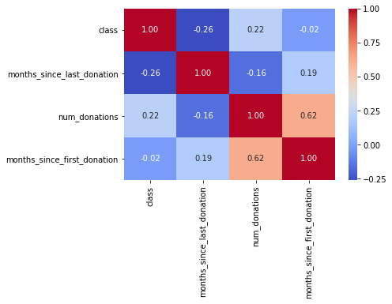

```python
# Correlation matrix between numerical values (SibSp Parch Age and Fare values) and Survived
g = sns.heatmap(df[["class","months_since_last_donation","num_donations","months_since_first_donation"]].corr(),annot=True, fmt = ".2f", cmap = "coolwarm")
```

It doesn't mean that the other features are not usefull. num_donations in these features can be correlated with the class. To determine this, we need to explore in detail these features

#### num_donations

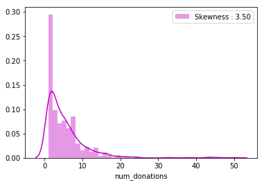

```python
# Explore num_donations distribution
g = sns.distplot(df["num_donations"], color="m", label="Skewness : %.2f"%(df["num_donations"].skew()))
g = g.legend(loc="best")
```

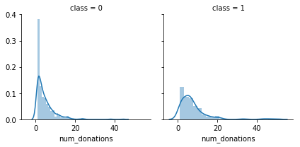

```python
g = sns.FacetGrid(df, col='class')
g = g.map(sns.distplot, "num_donations")
```

We notice that num_donations distributions are not the same in the class 1 and class 0 subpopulations. Indeed, there is a peak corresponding to the people who have donated only 0-4 time will not donate blood.

It seems that people have donated more number of times are more likely to donate blood.

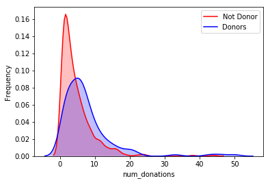

```python
# Explore num_donations distibution
g = sns.kdeplot(df["num_donations"][(df["class"] == 0)], color="Red", shade = True)
g = sns.kdeplot(df["num_donations"][(df["class"] == 1)], ax =g, color="Blue", shade= True)
g.set_xlabel("num_donations")
g.set_ylabel("Frequency")
g = g.legend(["Not Donor","Donors"])
```

Here we can see a strong co relation that people who have donated in 7-20 time will more likely to donate blood.

#### months_since_last_donation

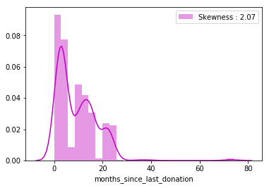

```python
# Explore months_since_last_donation distribution
g = sns.distplot(df["months_since_last_donation"], color="m", label="Skewness : %.2f"%(df["months_since_last_donation"].skew()))
g = g.legend(loc="best")
```

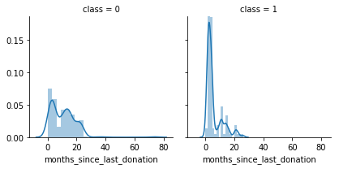

```python
g = sns.FacetGrid(df, col='class')
g = g.map(sns.distplot, "months_since_last_donation")
```

We notice that months_since_last_donation distributions are not the same in the class 1 and class 0 subpopulations. Indeed, there is a peak corresponding to the people who have donated recently(in 0-3 months) will donate blood.

It seems that people have donated recently are more likely to donate blood.

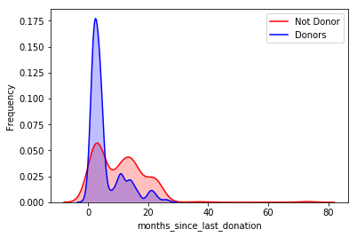

```python
# Explore months_since_last_donation distibution
g = sns.kdeplot(df["months_since_last_donation"][(df["class"] == 0)], color="Red", shade = True)
g = sns.kdeplot(df["months_since_last_donation"][(df["class"] == 1)], ax =g, color="Blue", shade= True)
g.set_xlabel("months_since_last_donation")
g.set_ylabel("Frequency")
g = g.legend(["Not Donor","Donors"])
```

Here we can see a strong co relation that people who have donated in 0-5 motnhs will more likely to donate blood.

#### months_since_first_donation

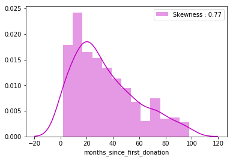

```python
# Explore months_since_last_donation distribution
g = sns.distplot(df["months_since_first_donation"], color="m", label="Skewness : %.2f"%(df["months_since_first_donation"].skew()))
g = g.legend(loc="best")
```

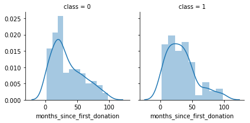

```python
g = sns.FacetGrid(df, col='class')
g = g.map(sns.distplot, "months_since_first_donation")
```

We notice that months_since_first_donation distributions are not the same in the class 1 and class 0 subpopulations. Indeed, there is a peak corresponding to the people who have just donated recently(in 6-20 months) will not donate blood.

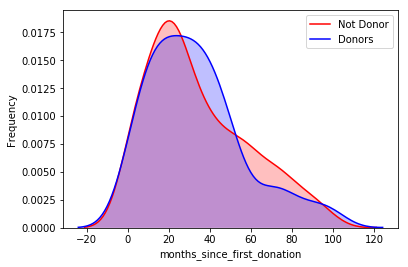

```python
# Explore months_since_first_donation distibution
g = sns.kdeplot(df["months_since_first_donation"][(df["class"] == 0)], color="Red", shade = True)
g = sns.kdeplot(df["months_since_first_donation"][(df["class"] == 1)], ax =g, color="Blue", shade= True)
g.set_xlabel("months_since_first_donation")
g.set_ylabel("Frequency")
g = g.legend(["Not Donor","Donors"])
```

#### vol_donations

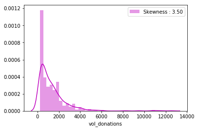

```python
# Explore months_since_last_donation distribution
g = sns.distplot(df["vol_donations"], color="m", label="Skewness : %.2f"%(df["vol_donations"].skew()))
g = g.legend(loc="best")
```

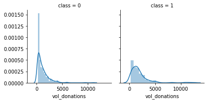

```python
g = sns.FacetGrid(df, col='class')
g = g.map(sns.distplot, "vol_donations")
```

We can not determine anything from this graph about the vol_donations. So lets try to build some different intuitions.

### Correlation between frequency and monetary

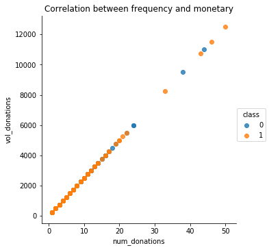

```python
plt.figure(figsize=(15,10));
_ = sns.lmplot(x='num_donations',
               y='vol_donations',
               hue='class',
               fit_reg=False,
               data=df);
_ = plt.title("Correlation between frequency and monetary");
plt.show();
```

Frequency and monetary values are highly correlated. So we can use onle the frequency

##### BOX PLOT (To see the outliers)

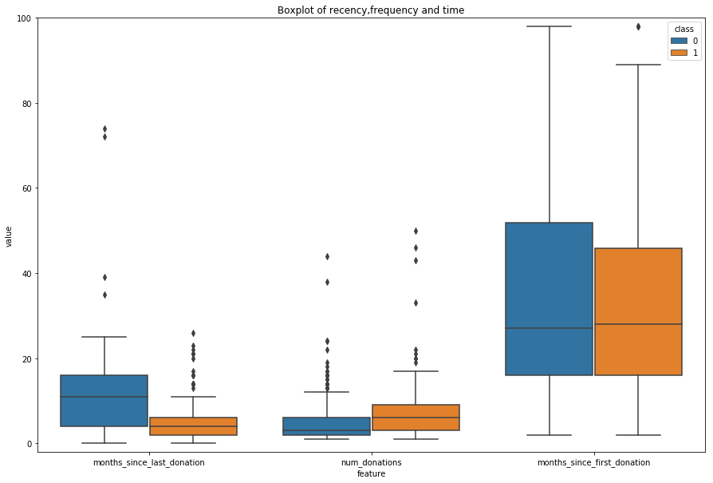

```python
df_long = pd.melt(df,id_vars='class',var_name='feature')
plt.figure(figsize=(15,10))
_ = sns.boxplot(x='feature',y='value',hue='class',data=df_long[df_long.feature!='vol_donations'])
plt.margins(0.02)
_ = plt.title('Boxplot of recency,frequency and time')
plt.show()
```

## 5. MODELING

```python
# We'll drop 'vol_donations' feature from our training data since it has high correlation to 'frequency'.
X = df.iloc[:, [0,1,3]].values
y = df.iloc[:, 4].values
```

```python
X
```

```
array([[ 2, 50, 98],
       [ 0, 13, 28],
       [ 1, 16, 35],
       ...,
       [21,  2, 52],
       [39,  1, 39],
       [72,  1, 72]], dtype=int64)
```

```python
# Splitting the dataset into the Training set and Test set
from sklearn.cross_validation import train_test_split
X_train, X_test, y_train, y_test = train_test_split(X, y, test_size = 0.1, random_state = RANDOM_STATE)
```

### 5.1 Feature Scaling

```python
# Feature Scaling
from sklearn.preprocessing import StandardScaler
sc = StandardScaler()
X_train_scaled = sc.fit_transform(X_train)
X_test_scaled = sc.transform(X_test)
```

```python
X_train_scaled.mean(),X_train_scaled.std()
```

```
(-6.629903261596816e-17, 1.0000000000000004)
```

```python
X_test_scaled.mean(),X_test_scaled.std()
```

```
(-0.10843613879395507, 0.8766287211421586)
```

### Resampling and Visualizations

```python
# Instanciate a PCA object for the sake of easy visualisation
pca = PCA(n_components=2,random_state=RANDOM_STATE)
# Fit and transform x to visualise inside a 2D feature space
X_vis = pca.fit_transform(X_train_scaled)

pca_original_df = pd.DataFrame(X_vis,y_train).reset_index()
pca_original_df.columns = ['class','x','y']

# Apply SMOTE + Tomek links
sm = SMOTETomek()
X_resampled, y_resampled = sm.fit_sample(X_train_scaled, y_train)
X_res_vis = pca.transform(X_resampled)

pca_resampled_df = pd.DataFrame(X_res_vis,y_resampled).reset_index()
pca_resampled_df.columns = ['class','x','y']
```

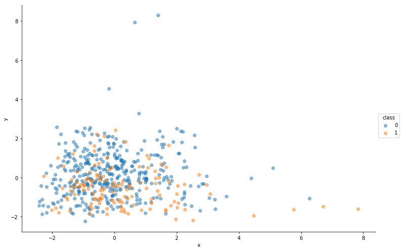

```python
#Visualizing original data in 2D


_ = sns.lmplot(x='x',
               y='y',
               hue='class',
               x_jitter=True,
               y_jitter=True,
               fit_reg=False,
               size=7,
               aspect = 1.5,
               data=pca_original_df,
               scatter_kws={'alpha':0.5})
```

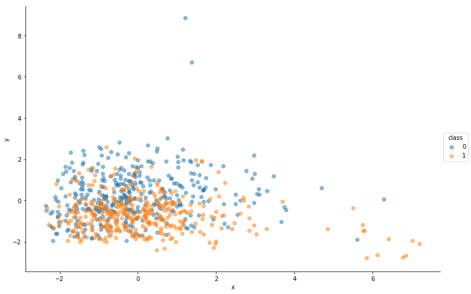

```python
#Visualizing resampled data in 2D


_ = sns.lmplot(x='x',
               y='y',
               hue='class',
               x_jitter=True,
               y_jitter=True,
               fit_reg=False,
               size=7,
               aspect = 1.5,
               data=pca_resampled_df,
               scatter_kws={'alpha':0.5})
```

### 5.2 ML Model

```python
from sklearn.svm import SVC
from sklearn.linear_model import LogisticRegression
from sklearn.ensemble import RandomForestClassifier
from keras.wrappers.scikit_learn import KerasClassifier
np.random.seed(2017)

early_stopping_monitor = EarlyStopping(monitor='val_loss',patience=5)

def create_mlp():
    model = Sequential()
    model.add(Dropout(0.25,input_shape=(x_train_scaled.shape[1],)))
    model.add(Dense(100,activation='relu',input_shape=(x_train_scaled.shape[1],)))
    model.add(Dropout(0.25))
    model.add(Dense(100,activation='relu'))
    model.add(Dropout(0.25))
    model.add(Dense(100,activation='relu'))
    model.add(Dense(2,activation='sigmoid'))
    model.compile(optimizer='adam',loss='binary_crossentropy',metrics=['accuracy'])
    return model


svc = SVC(verbose=1,C=10,gamma=0.1,kernel='rbf',random_state=2017,probability=True);
svc.fit(X_train_scaled,y_train)

logit_model = LogisticRegression(random_state=2017)
logit_model.fit(X_train_scaled,y_train)

rf = RandomForestClassifier(n_estimators=100,max_depth=6,class_weight='balanced',n_jobs=4,random_state=2017)
rf.fit(X_train_scaled,y_train)

mlp = KerasClassifier(build_fn=create_mlp, epochs=20, batch_size=10, validation_split=0.2,verbose=False)


models = {'SVC': svc,
          'Logistic Regression': logit_model,
          'Random Forest': rf,
          'mlp': mlp
         }
```

```
[LibSVM]
```

### 5.3 Grid search for the best parameters of our models

```python
from sklearn.model_selection import GridSearchCV

parameters = {'kernel':('linear', 'rbf'), 'C':[1, 10,100,1000], 'gamma': [1e-1,1e-2,1e-3,1,10,100]}
svc_grid = SVC(probability=True,verbose=True)
clf = GridSearchCV(svc_grid, parameters,scoring='neg_log_loss',verbose=True,n_jobs=4)
clf.fit(X_train_scaled,y_train)
```

```
Fitting 3 folds for each of 48 candidates, totalling 144 fits
```

```
[Parallel(n_jobs=4)]: Done  65 tasks      | elapsed:    4.1s
[Parallel(n_jobs=4)]: Done 144 out of 144 | elapsed:  9.8min finished
```

```
[LibSVM]
```

```
GridSearchCV(cv=None, error_score='raise',
       estimator=SVC(C=1.0, cache_size=200, class_weight=None, coef0=0.0,
  decision_function_shape='ovr', degree=3, gamma='auto', kernel='rbf',
  max_iter=-1, probability=True, random_state=None, shrinking=True,
  tol=0.001, verbose=True),
       fit_params=None, iid=True, n_jobs=4,
       param_grid={'kernel': ('linear', 'rbf'), 'C': [1, 10, 100, 1000], 'gamma': [0.1, 0.01, 0.001, 1, 10, 100]},
       pre_dispatch='2*n_jobs', refit=True, return_train_score='warn',
       scoring='neg_log_loss', verbose=True)
```

```python
pd.DataFrame(clf.cv_results_)[['mean_test_score',
                               'mean_train_score',
                               'param_C',
                               'param_gamma',
                               'param_kernel',
                               'rank_test_score']].sort_values('rank_test_score')[:5]
```

|  | mean_test_score | mean_train_score | param_C | param_gamma | param_kernel | rank_test_score |
| --- | --- | --- | --- | --- | --- | --- |
| 7 | -0.506053 | -0.464963 | 1 | 1 | rbf | 1 |
| 19 | -0.522150 | -0.452436 | 10 | 1 | rbf | 2 |
| 13 | -0.523577 | -0.489671 | 10 | 0.1 | rbf | 3 |
| 39 | -0.524934 | -0.493441 | 1000 | 0.01 | rbf | 4 |
| 27 | -0.525992 | -0.508275 | 100 | 0.01 | rbf | 5 |

### 5.4 Cross Validation

```python
np.random.seed(RANDOM_STATE)
print("Cross-validation score")
print("=========================")
for model_name, model in models.items():
    if model_name=='mlp':
        cv_score = cross_val_score(estimator=model,X=X_train_scaled,y=to_categorical(y_train),
                                   scoring='neg_log_loss',
                                   cv=10,
                                   n_jobs=4,
                                   verbose=False,
                                   fit_params={'callbacks':[early_stopping_monitor]})
    else:
        cv_score = cross_val_score(estimator=model,
                                   X=X_train_scaled,
                                   y=y_train,
                                   cv=10,
                                   n_jobs=4,
                                   scoring='neg_log_loss',
                                   verbose=False)
    print(model_name," ",-cv_score.mean(),"+/-",cv_score.std())
```

[output not shown]

```
Cross-validation score
=========================
SVC   0.5229279792217028 +/- 0.042795178683074746
Logistic Regression   0.49666663540225314 +/- 0.02933488441096068
Random Forest   0.563135659374043 +/- 0.04857618351741091
```

### 5.5 Testing the models on test set

```python
np.random.seed(RANDOM_STATE)
print("Log loss")
print("-------------")
for model_name,model in models.items():
    if model_name == 'mlp':
        mlp.fit(X_train_scaled,to_categorical(y_train)) #need to fit the model before predicting
    y_pred = model.predict_proba(X_test_scaled)
    print(model_name,": ",log_loss(y_test,y_pred))
```

[output not shown]

# Submission

```python
def create_submission(clf):
    test = pd.read_csv("test.csv")
    test.columns = ['id','months_since_last_donation','num_donations','vol_donations','months_since_first_donation']
    submit_id, submit_test = test['id'] , test.drop(['id','vol_donations'],axis=1)
    submit_test_scaled = sc.transform(submit_test) #scale the data
    predictions = clf.predict_proba(submit_test_scaled)
    predictions = predictions[:,1] #only predictions for class-1 needs to be submitted
    pred_report = pd.DataFrame(predictions.tolist(),index=submit_id,columns=["Made Donation in March 2007"])
    return pred_report
```

### Save the DataBase

```python
# SVM
a = create_submission(svm)
```

```python
a.to_csv("Submission_svm.csv")
```